# Tree Visualization

Guangchuang Yu (guangchuangyu@gmail.com) and Tommy Tsan-Yuk Lam (ttylam@hku.hk) School of Public Health, The University of Hong Kong

2016-01-13

To view a phylogenetic tree, we first need to parse the tree file into `R`. The `ggtree` package supports many file format including output files of commonly used software packages in evolutionary biology. For more details, plase refer to the Tree Data Import vignette.

```r
library("ggtree")
nwk <- system.file("extdata", "sample.nwk", package="ggtree")
tree <- read.tree(nwk)
```

# Viewing tree with `ggtree`

The `ggtree` package extends *`ggplot2`* package to support viewing phylogenetic tree. It implements *`geom_tree`* layer for displaying phylogenetic trees, as shown below:

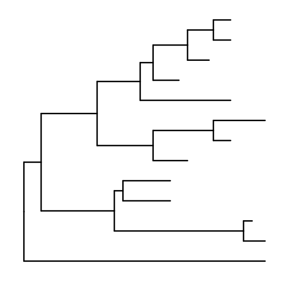

```r
ggplot(tree, aes(x, y)) + geom_tree() + theme_tree()
```

The function, *`ggtree`*, was implemented as a short cut to visualize a tree, and it works exactly the same as shown above.

*`ggtree`* takes all the advantages of *`ggplot2`*. For example, we can change the color, size and type of the lines as we do with *`ggplot2`*.

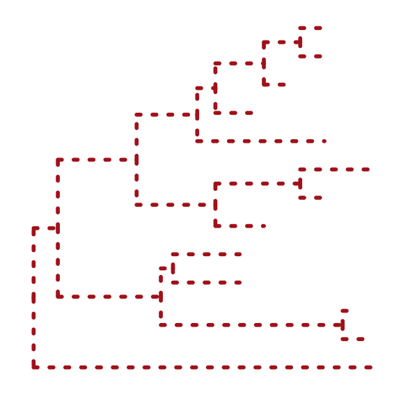

```r
ggtree(tree, color="firebrick", size=1, linetype="dotted")
```

By default, the tree is viewed in ladderize form, user can set the parameter *`ladderize = FALSE`* to disable it.

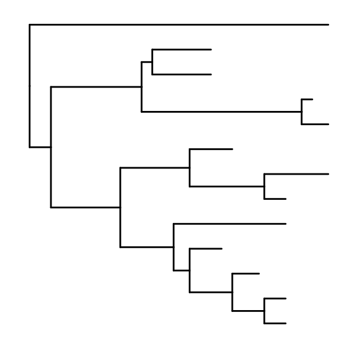

```r
ggtree(tree, ladderize=FALSE)
```

The *`branch.length`* is used to scale the edge, user can set the parameter *`branch.length = "none"`* to only view the tree topology (cladogram) or other numerical variable to scale the tree (e.g. *dN/dS*, see also in Tree Annotation vignette).

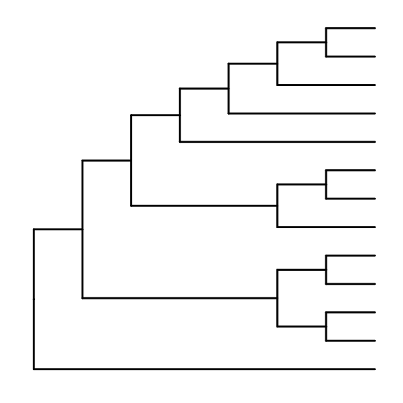

```r
ggtree(tree, branch.length="none")
```

# Layout

Currently, *`ggtree`* supports several layouts, including:

- `rectangular` (by default)
- `slanted`
- `fan` or `circular`

for `Phylogram` (by default) and `Cladogram` if user explicitly setting `branch.length='none'`. `ggtree` also supports `unrooted` layout.

## Phylogram

**`rectangular`**

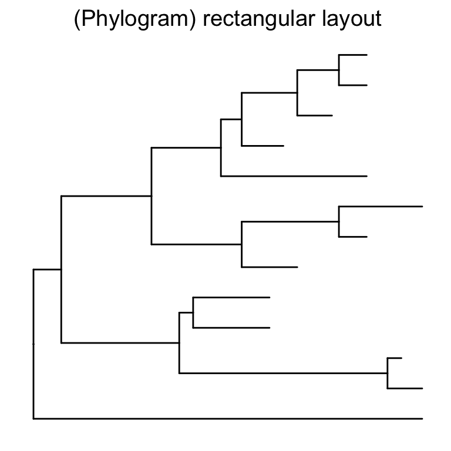

```r
ggtree(tree) + ggtitle("(Phylogram) rectangular layout")
```

**`slanted`**

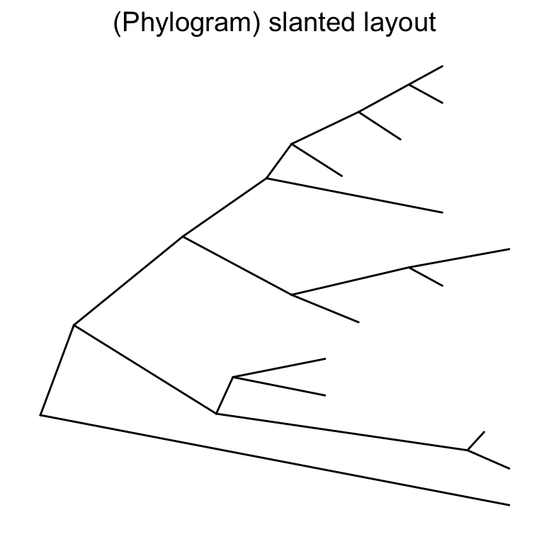

```r
ggtree(tree, layout="slanted") + ggtitle("(Phylogram) slanted layout")
```

**`circular`**

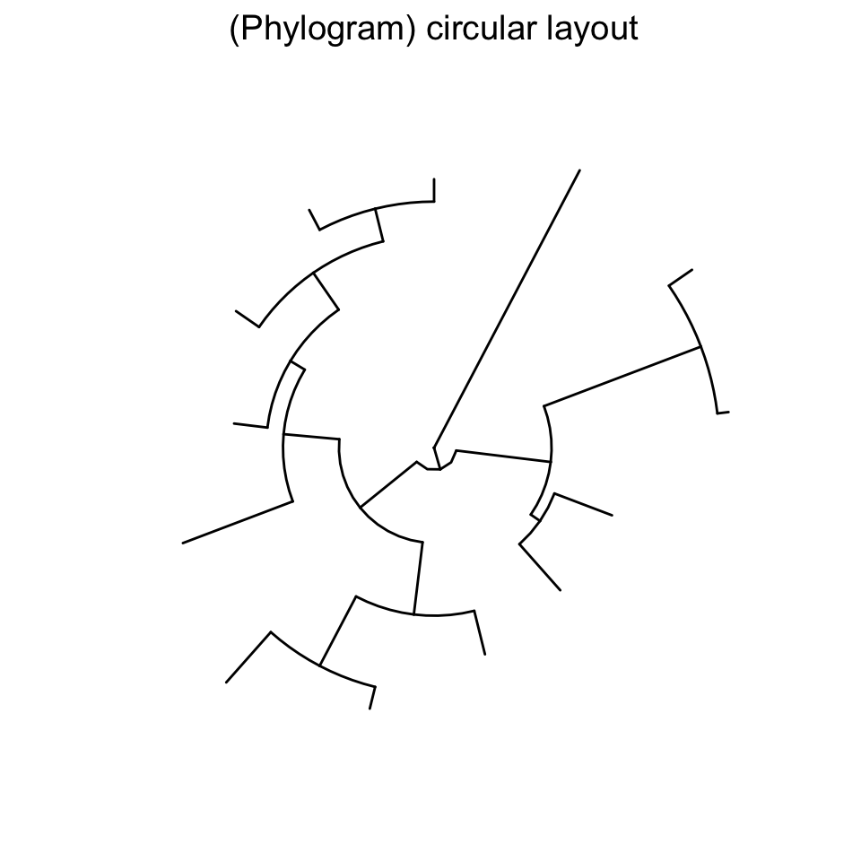

```r
ggtree(tree, layout="circular") + ggtitle("(Phylogram) circular layout")
```

## Cladogram

**`rectangular`**

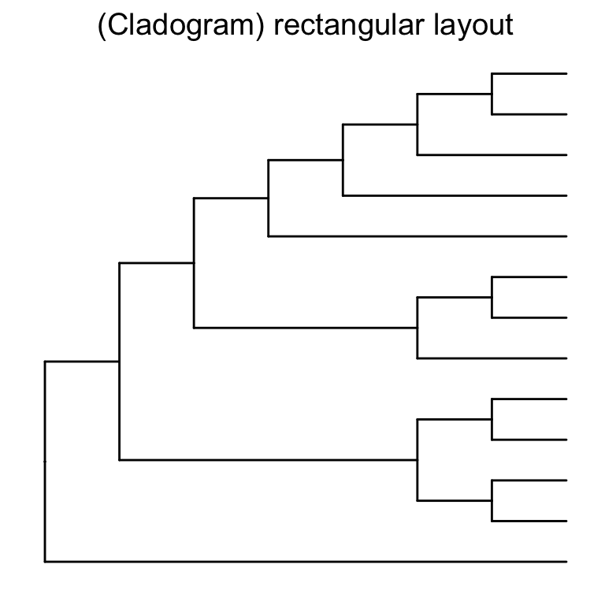

```r
ggtree(tree, branch.length='none') + ggtitle("(Cladogram) rectangular layout")
```

**`slanted`**

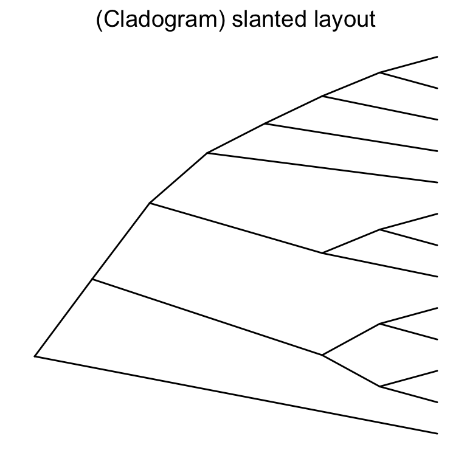

```r
ggtree(tree, layout="slanted", branch.length='none') + ggtitle("(Cladogram) slanted layout")
```

**`circular`**

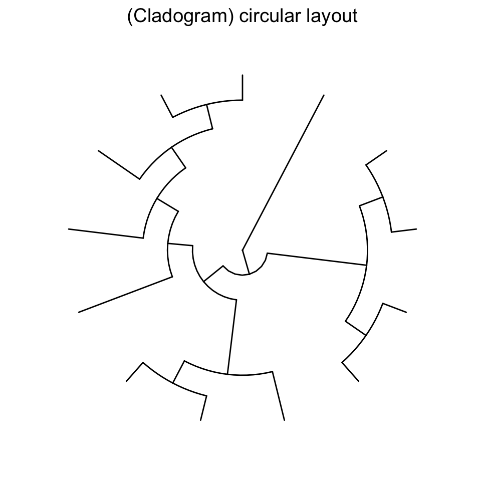

```r
ggtree(tree, layout="circular", branch.length="none") + ggtitle("(Cladogram) circular layout")
```

## Unrooted

Unrooted layout was implemented by the *`equal-angle algorithm`* that described in *Inferring Phylogenies*<sup>1</sup>.

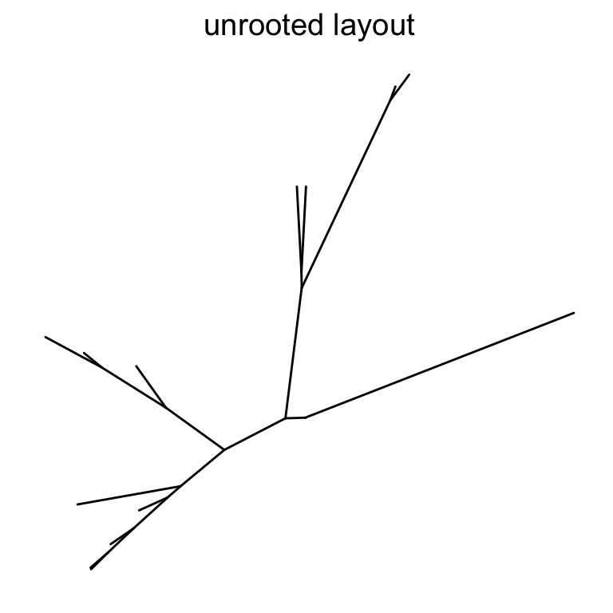

```r
ggtree(tree, layout="unrooted") + ggtitle("unrooted layout")
```

## Time-scaled tree

A phylogenetic tree can be scaled by time (time-scaled tree) by specifying the parameter, `mrsd` (most recent sampling date).

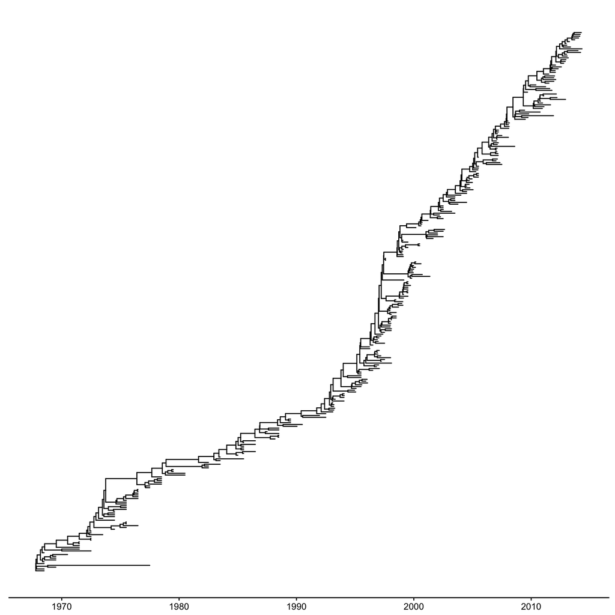

```r
tree2d <- read.beast(system.file("extdata", "twoD.tree", package="ggtree"))
ggtree(tree2d, mrsd = "2014-05-01") + theme_tree2()
```

## Two dimensional tree

`ggtree` implemented two dimensional tree. It accepts parameter *`yscale`* to scale the y-axis based on the selected tree attribute. The attribute should be numerical variable. If it is *character*/*category* variable, user should provides a name vector of mapping the variable to numeric by passing it to parameter *`yscale_mapping`*.

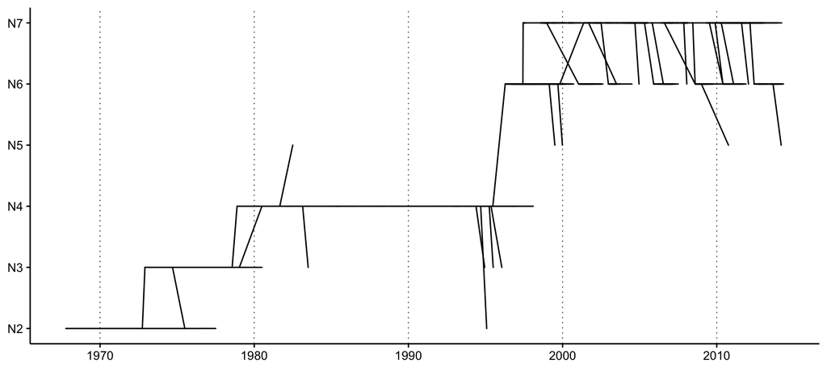

```r
ggtree(tree2d, mrsd = "2014-05-01",
       yscale="NGS", yscale_mapping=c(N2=2, N3=3, N4=4, N5=5, N6=6, N7=7)) +
           theme_classic() +
               theme(panel.grid.major=element_line(color="grey20", linetype="dotted", size=.3),
                     panel.grid.major.y=element_blank()) +
                         scale_y_continuous(labels=paste0("N", 2:7))
```

In this example, the figure demonstrates the quantity of *y* increase along the trunk. User can highlight the trunk with different line size or color using the functions described in Tree Manipulation vignette.

# Displaying tree scale (evolution distance)

To show tree scale, user can use `geom_treescale()` layer.

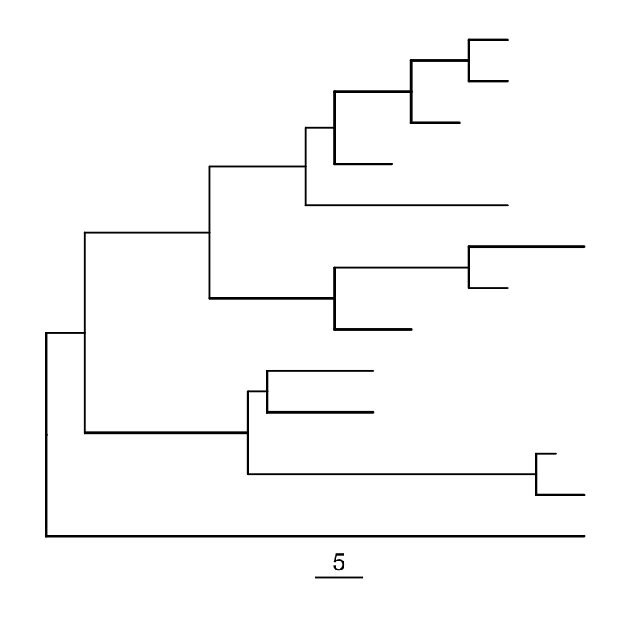

```r
ggtree(tree) + geom_treescale()
```

`geom_treescale()` supports the following parameters:

- `x` and `y` for tree scale position
- `width` for the length of the tree scale
- `fontsize` for the size of the text
- `linesize` for the size of the line
- `offset` for relative position of the line and the text
- `color` for color of the tree scale

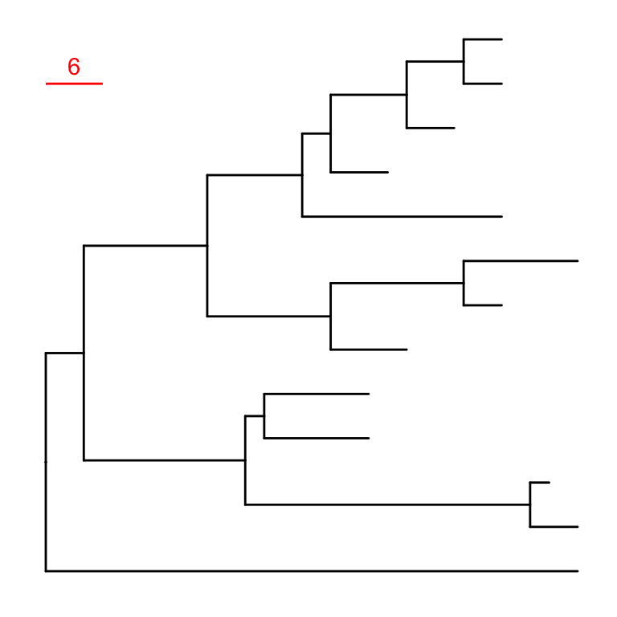

```r
ggtree(tree)+geom_treescale(x=0, y=12, width=6, color='red')
```

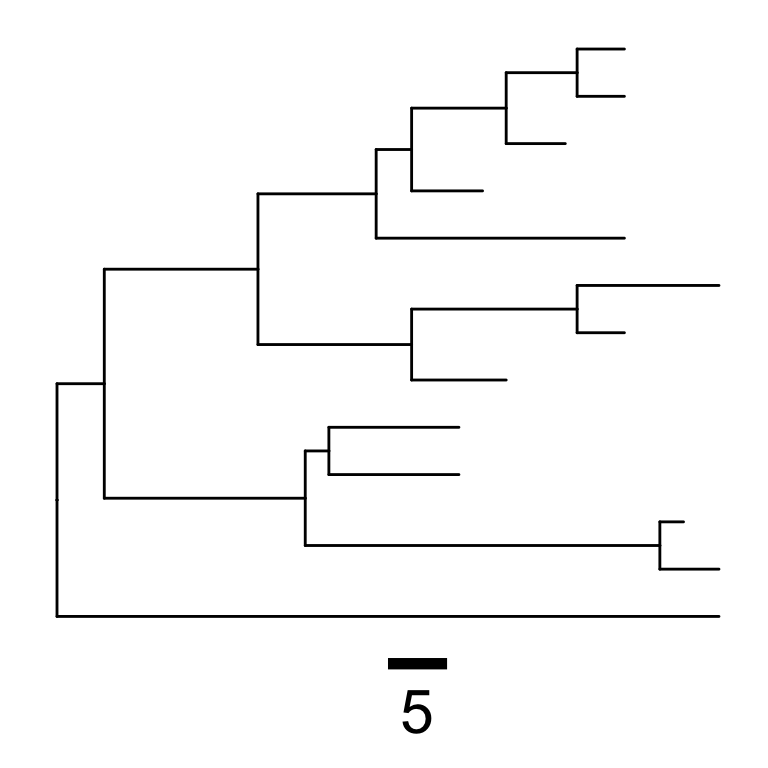

```r
ggtree(tree)+geom_treescale(fontsize=8, linesize=2, offset=-1)
```

We can also use `theme_tree2()` to display the tree scale by adding `x axis`.

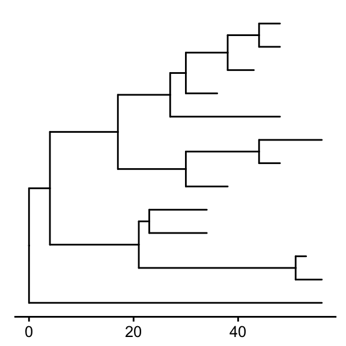

```r
ggtree(tree) + theme_tree2()
```

Tree scale is not restricted to evolution distance, `ggtree` can re-scale the tree with other numerical variable. More details can be found in the Tree Annotation vignette.

# Displaying nodes/tips

Showing all the internal nodes and tips in the tree can be done by adding a layer of points using *`geom_nodepoint`*, *`geom_tippoint`* or *`geom_point`*.

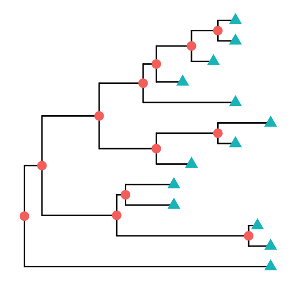

```r
ggtree(tree)+geom_point(aes(shape=isTip, color=isTip), size=3)
```

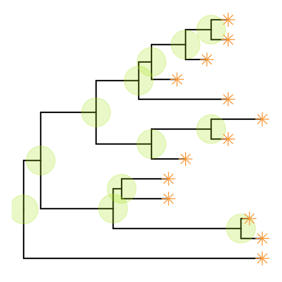

```r
p <- ggtree(tree) + geom_nodepoint(color="#b5e521", alpha=1/4, size=10)
p + geom_tippoint(color="#FDAC4F", shape=8, size=3)
```

## Displaying labels

Users can use *`geom_text`* to display the node (if availabel) and tip labels simultaneously or `geom_tiplab` to only display tip labels:

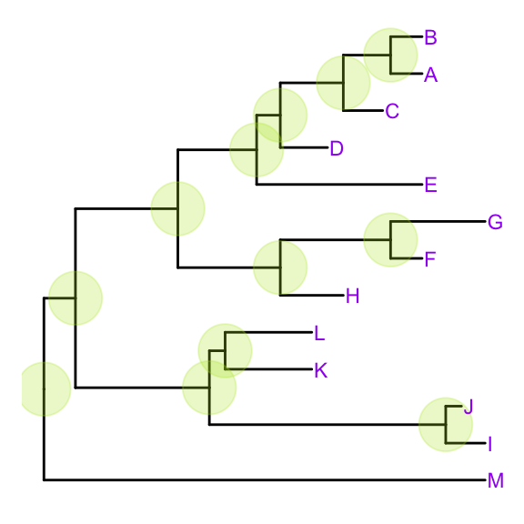

```r
p + geom_tiplab(size=3, color="purple")
```

For *`circular`* and *`unrooted`* layout, `ggtree` supports rotating node labels according to the angles of the branches.

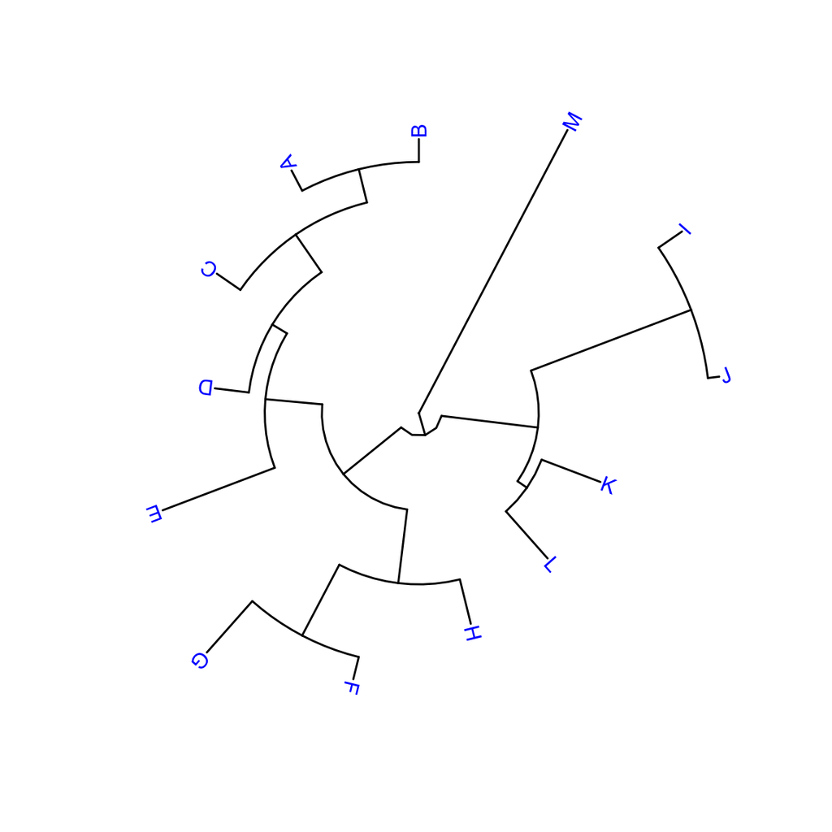

```r
ggtree(tree, layout="circular") + geom_tiplab(aes(angle=angle), color='blue')
```

By default, the positions are based on the node positions, we can change them to based on the middle of the branch/edge.

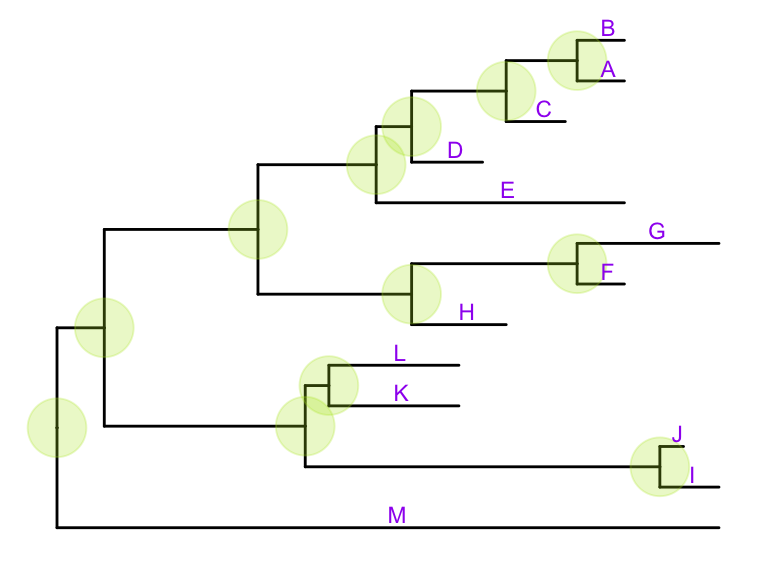

```r
p + geom_tiplab(aes(x=branch), size=3, color="purple", vjust=-0.3)
```

Based on the middle of branch is very useful when annotating transition from parent node to child node.

# update tree view with a new tree

In previous example, we have a *`p`* object that stored the tree viewing of 13 tips and internal nodes highlighted with specific colored big dots. If users want to apply this pattern (we can imaging a more complex one) to a new tree, you don’t need to build the tree step by step. `ggtree` provides an operator, *`%<%`*, for applying the visualization pattern to a new tree.

For example, the pattern in the *`p`* object will be applied to a new tree with 50 tips as shown below:

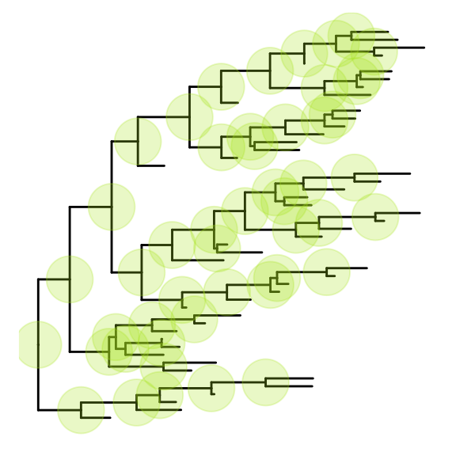

```r
p %<% rtree(50)
```

Another example can be found in the Tree Data Import vignette.

# theme

`theme_tree()` defined a totally blank canvas, while *`theme_tree2()`* adds phylogenetic distance (via x-axis). These two themes all accept a parameter of *`bgcolor`* that defined the background color.

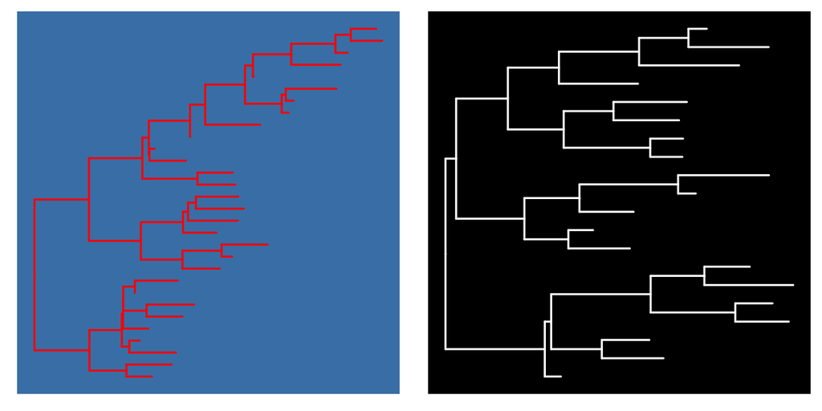

```r
grid.arrange(
    ggtree(rtree(30), color="red") + theme_tree("steelblue"),
    ggtree(rtree(20), color="white") + theme_tree("black"),
    ncol=2)
```

# References

1. Felsenstein, J. *Inferring phylogenies*. (Sinauer Associates, 2003).